# hyperparameter-tuning

```r
library(tidyverse)
library(tidymodels)
library(glue)
library(powerjoin)
library(vip)
library(baguette)
library(ggthemes)
library(patchwork)
library(ranger)
library(xgboost)
library(visdat)
library(dials)
library(tune)
```

# Read in the data using map, read_delim() and powerjoin::power_full_join()

```r
# download data
root  <- 'https://gdex.ucar.edu/dataset/camels/file'

#download the documentation PDF which provides a descriptions for the various columns
download.file('https://gdex.ucar.edu/dataset/camels/file/camels_attributes_v2.0.pdf',
              'data/camels_attributes_v2.0.pdf')

# download the .txt files that store the actual data documented in the PDF. Create a vector storing the data types/file names we want to download:

#data from the pdf that we want
types <- c("clim", "geol", "soil", "topo", "vege", "hydro")

# Using glue, we can construct the needed URLs and file names for the data we want to download:

# Where the files live online ...
remote_files  <- glue('{root}/camels_{types}.txt')
# where we want to download the data ...
local_files   <- glue('data/camels_{types}.txt')

# asking walk2 to pass the first element of remote_files and the first element of local_files to the download.file function to download the data, and setting quiet = TRUE to suppress output. The process is then iterated for the second element of each vector, and so on.
walk2(remote_files, local_files, download.file, quiet = TRUE)

# Read and merge data
camels <- map(local_files, read_delim, show_col_types = FALSE)

#we are join to merge every data.frame in the list (n = 6) by the shared gauge_id column. Since we want to keep all data, we want a full join.
camels <- power_full_join(camels ,by = 'gauge_id')
```

# Clean the data using dplyr, EDA (skimr, visdat, ggpubr), and other means to ensure it is in a good form for modeling.

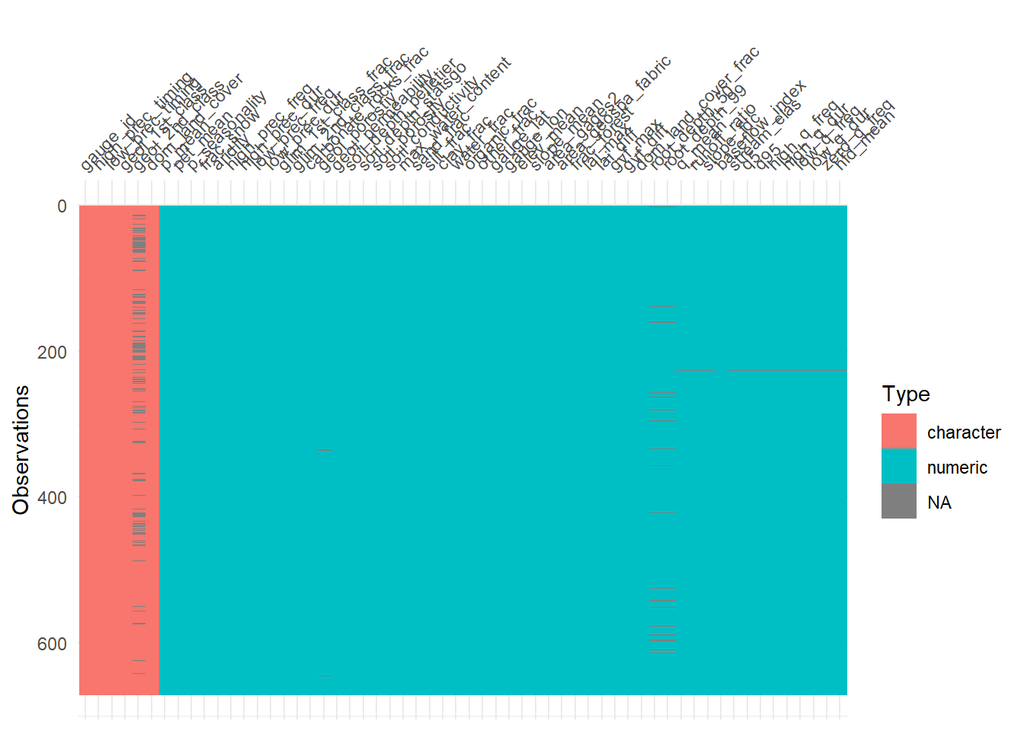

```r
#look at data structure and where na values are
vis_dat(camels)
```

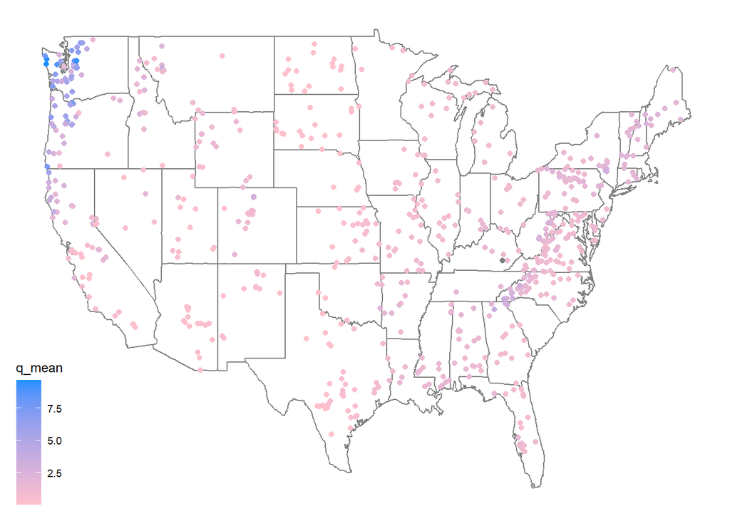

```r
# EDA visualizion
ggplot(data = camels, aes(x = gauge_lon, y = gauge_lat)) +
  borders("state", colour = "gray50") +
  geom_point(aes(color = q_mean)) +
  scale_color_gradient(low = "pink", high = "dodgerblue") +
  ggthemes::theme_map()
```

# Data Splitting

```r
#set seed
set.seed(123)

#transform the q_mean column to a log scale. Remember it is error prone to apply transformations to the outcome variable within a recipe
camels_clean <- camels |>
  mutate(logQmean = log(q_mean)) %>%
  select(logQmean,aridity,pet_mean, gauge_lat, gauge_lon) %>%
  drop_na()

# split data: use 80% of the data for training and 20% for testing with no stratification
camels_split <- initial_split(camels_clean, prop = 0.8)
camels_train <- training(camels_split)
camels_test  <- testing(camels_split)

#create a 10-fold cross validation dataset to help us evaluate multi-model setups.
camels_cv <- vfold_cv(camels_train, v = 10)
```

# Feature Engineering

```r
#create recipe object with recipe(). Based on how you want to predict q_mean and the data should be the training data.

rec <-recipe(logQmean ~. , data = camels_train) %>%
  step_normalize(all_predictors()) %>%
  # Log transform the predictor variables (aridity and pet_mean)
  #step_log(all_predictors()) %>%
  # Add an interaction term between aridity and p_mean
  step_interact(terms = ~ aridity:pet_mean) %>%
  # Drop any rows with missing values in the pred
  #step_naomit(all_predictors(), all_outcomes()) %>%
  step_rm(gauge_lat, gauge_lon)



#problem with step_rm: exclude these columns from being used as predictors, but still keep them in the dataset for later (e.g., to join, identify sites, or plot
```

# Resampling and Modeling Data: Training data is now ready to be used for model training and you have a preprocessor that you can iterate over.

Build Resamples: This step is done above in the data splitting portion

# Build 3 Candidate Models: A model is defined by a specification, an engine, and a mode.

```r
#Define a random forest model using the rand_forest function, set engine to ranger and mode to regression
rf_model2 <- rand_forest() %>%
  set_engine("ranger", importance = "impurity") %>%
  set_mode("regression")

#Define two other models of choice
#linear model
lm_model2 <- linear_reg() %>%
  # define the engine
  set_engine("lm") %>%
  # define the mode
  set_mode("regression")

#boost model
boost_model2 <- boost_tree() %>%
  # define the engine
  set_engine("xgboost") %>%
  # define the mode
  set_mode("regression")
```

#Test the Models

linear regression, xgboost, and random forest models:

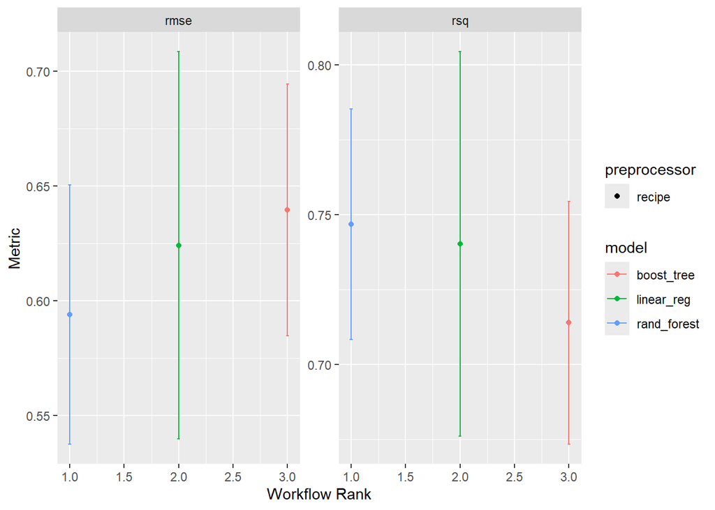

```r
#Create a workflow object, add recipe, add the model, to model to resamples
wf2 <- workflow_set(list(rec), list(lm_model2, boost_model2,rf_model2)) %>%
  workflow_map('fit_resamples', resamples = camels_cv)

# Use autoplot and rank_results to compare the models.
autoplot(wf2)
```

```r
rank_results(wf2, rank_metric = "rsq", select_best = TRUE)
```

```
# A tibble: 6 × 9
  wflow_id          .config .metric  mean std_err     n preprocessor model  rank
  <chr>             <chr>   <chr>   <dbl>   <dbl> <int> <chr>        <chr> <int>
1 recipe_rand_fore… Prepro… rmse    0.594  0.0344    10 recipe       rand…     1
2 recipe_rand_fore… Prepro… rsq     0.747  0.0234    10 recipe       rand…     1
3 recipe_linear_reg Prepro… rmse    0.624  0.0513    10 recipe       line…     2
4 recipe_linear_reg Prepro… rsq     0.740  0.0389    10 recipe       line…     2
5 recipe_boost_tree Prepro… rmse    0.640  0.0334    10 recipe       boos…     3
6 recipe_boost_tree Prepro… rsq     0.714  0.0247    10 recipe       boos…     3
```

# Model Selection

Based on the visualized metrics, select a model that you think best performs. Describe the reason for your choice using the metrics.

```r
rank_results(wf2, rank_metric = "rsq", select_best = TRUE)
```

```
# A tibble: 6 × 9
  wflow_id          .config .metric  mean std_err     n preprocessor model  rank
  <chr>             <chr>   <chr>   <dbl>   <dbl> <int> <chr>        <chr> <int>
1 recipe_rand_fore… Prepro… rmse    0.594  0.0344    10 recipe       rand…     1
2 recipe_rand_fore… Prepro… rsq     0.747  0.0234    10 recipe       rand…     1
3 recipe_linear_reg Prepro… rmse    0.624  0.0513    10 recipe       line…     2
4 recipe_linear_reg Prepro… rsq     0.740  0.0389    10 recipe       line…     2
5 recipe_boost_tree Prepro… rmse    0.640  0.0334    10 recipe       boos…     3
6 recipe_boost_tree Prepro… rsq     0.714  0.0247    10 recipe       boos…     3
```

The engine for the random forest model is ranger, while the mode is regression. This type of model is good for this data set because it’s small and easy to train and predict without the risk of over fitting. It also helps to learn about the interactions between other variables in the tree-building process.

# Model Tuning

Define a tunable model: Be sure to set the mode and engine as you did above but this time specify at least 2 hyperparameters to tune using the tune() function. These are set in the model specification and options can be found in the documentation for the model you are using.

```r
#check tunable parameters for rand_forest
?rand_forest
```

```
starting httpd help server ... done
```

```r
#mtry: Number of predictors randomly sampled at each split.
#Type: Integer
#Effect: Controls how diverse the trees are. Lower values increase diversity, but may reduce accuracy

#min_n: Minimum number of observations required to make a further split in a node.
#Type: Integer
#Effect: Controls how deep the trees can grow. Larger min_n means shallower trees, which helps avoid overfitting.

rf_tunable <- rand_forest(
  mtry = tune(),
  min_n = tune()
) %>%
  set_engine("ranger") %>%
  set_mode("regression")
```

# Create a workflow

Now create a workflow object for this tune-able model and the recipe you created above.

```r
# Create the workflow by combining the recipe and model
rf_wf <- workflow(rec,rf_tunable)
```

# Check The Tunable Values / Ranges

In the above step, you created a workflow based on a model that has at least 2 tunable hyper parameters. Remember tune() is aware of the tunable parameters in the model specification and provides some basic defaults to tune across. We want to see what the range of those are! To do this, we can use the extract_parameter_set_dials() to return a list of the tunable parameters and their ranges. The output of this function is a data.frame.

Use the extract_parameter_set_dials(YOUR MODEL WORKFLOW) and save it to an object named dials. Check the dials$object slot to see the tunable parameters and their ranges.

```r
# Extract tunable parameters from the workflow
dials <- extract_parameter_set_dials(rf_wf)

# View the parameter ranges
dials$object
```

```
# Randomly Selected Predictors (quantitative)
```

```
Range: [1, ?]
```

```
Minimal Node Size (quantitative)
```

```
Range: [2, 40]
```

```r
#Lower mtry increases randomness and tree diversity (good for generalization).Too low might make trees less accurate.

#min_n : Higher min_n → simpler trees, less overfitting. Too high → underfitting (model too simple).
```

# Define the Search Space

OK, we now know the viable range of the hyperparameters we want to tune. The full range of these values is the complete search space in which the best options could live. Remember, there are two ways for our computer to search for the best combination:

1. Grid Search: This is a brute force approach that tests a predefined set of combinations. If elected as the search process, we need to specify how the set of combinations is chosen. This can be versions of evenly spaced (regular), random, or space filling curve/design (SFC/SFD).
2. Iterative: This is a more efficient approach that uses a set of algorithms to search the space. This is often more efficient than grid search, but can be less thorough.

Create a SFD Grid Object with 25 predefined combinations.

```r
#because undefinable max range of mtry, need to finalize dial before pass it into grid

# 2. Finalize parameter set based on training data (camels_train)
dials_final <- finalize(dials, camels_train)

# 3. Now you can create the grid with 25 combinations
my.grid <- grid_latin_hypercube(
  dials_final,
  size = 25)
#grid_latin_hypercube() samples evenly across the search space, but in a way that covers more ground than a regular grid with fewer points.
```

# Tune the Model

OK! You now have a tunable model workflow (rf_wf), a set of k-fold resamples to test over (folds), and a grid of hyperparameters to search (grid). Now we can use the tune_grid() function to search the grid and evaluate the model performance using the code below. In this example, we are doing 2 additional things. Setting a set of metrics to compute and saving the predictions to a output tibble.

Run the below code making any changes your need based on how you named your objects.

```r
model_params <- tune_grid(
  rf_wf,                 # your random forest workflow
  resamples = camels_cv, # your cross-validation folds
  grid = my.grid,        # the grid you built using Latin Hypercube
  metrics = metric_set(rmse, rsq, mae),
  control = control_grid(save_pred = TRUE)
)
```

```
→ A | warning: ! 5 columns were requested but there were 3 predictors in the data.
               ℹ 3 predictors will be used.
```

```
There were issues with some computations   A: x1
```

```
→ B | warning: ! 4 columns were requested but there were 3 predictors in the data.
               ℹ 3 predictors will be used.
```

[output not shown]

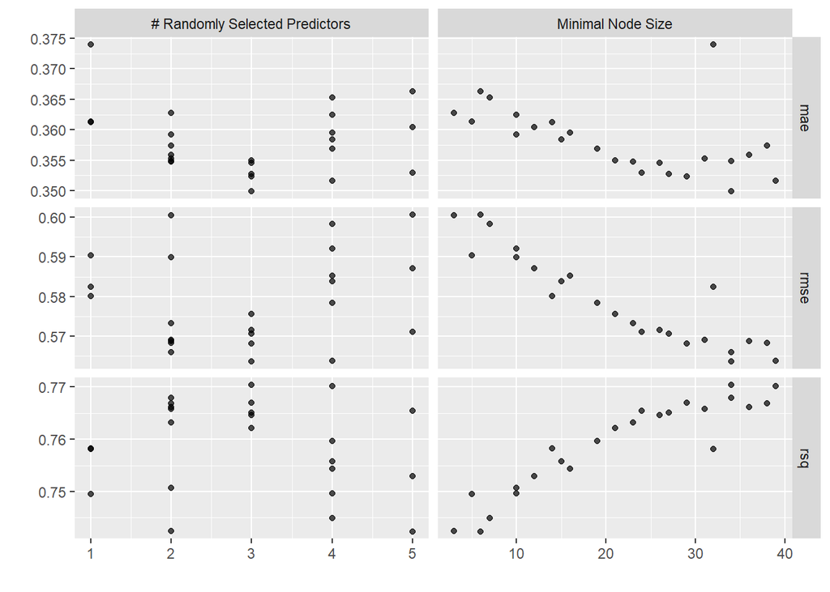

```r
autoplot(model_params)
```

```r
#Tests 25 random forest models (from my.grid).Across all resamples in camels_cv. Evaluates 3 metrics: RMSE, R², and MAE. Saves predictions from each resample so you can inspect them later
```

There is a randomly predicted side and minimal node side that show the metrics. It looks to be a scatter plot with clusters of points that show a trend with the rmse, rsq, and mae.